# PLN Regresión Logística

Arling

10/7/2021

# Preparación de datos

Lectura de datos

```r
`%notin%` = function(x,y) !(x %in% y)
```

```r
train.neg <- read_csv("data/train_neg.csv", col_names = c("id", "X"), skip = 1) %>% select(X)
train.pos <- read_csv("data/train_pos.csv", col_names = c("id", "X"), skip = 1) %>% select(X)
test.neg <- read_csv("data/test_neg.csv", col_names = c("id", "X"), skip = 1) %>% select(X)
test.pos <- read_csv("data/test_pos.csv", col_names = c("id", "X"), skip = 1) %>% select(X)
train.y <- read_csv("data/train_y.csv", col_names = c("id", "y"), skip = 1) %>% select(y)
test.y <- read_csv("data/test_y.csv", col_names = c("id", "y"), skip = 1) %>% select(y)
```

Se crea el conjunto de datos de entrenamiento y prueba.

```r
train.df <- train.pos %>% rbind(train.neg)
test.df <- test.pos %>% rbind(test.neg)

rm(train.pos, train.neg, test.pos, test.neg)
```

Longitud de los conjuntos de entrenamiento y prueba:

```r
length(train.df$X)
```

```
## [1] 8000
```

```r
length(test.df$X)
```

```
## [1] 2000
```

Se descarga el conjunto de stopwords, las opciones disponibles son `snowball`, `nltk` y `stopwords-iso`. Para este ejercicio se eligió `nltk`.

```r
library(stopwords)
# Selección de idioma para stopwords y stemming.
language <- "en"
stopwords <- stopwords(language, source = "nltk")
length(stopwords)
```

```
## [1] 179
```

Para realizar el stemming se utilizó la función `text_tokens`.

```r
library(corpus)
text <- "comuniti communiti love loving lovingly loved lover lovely love"
text_tokens(text, stemmer = language)[[1]]
```

```
## [1] "comun"     "communiti" "love"      "love"      "love"      "love"
## [7] "lover"     "love"      "love"
```

Un inconveniente del stemming de `R` ante `python` es que la función `text_tokens` no reconoce emoticones y los separa caracter por caracter. Por ejemplo:

```r
text <- "Hi, world :)"
text_tokens(text, stemmer = language)[[1]]
```

```
## [1] "hi"    ","     "world" ":"     ")"
```

En el documento `emoticons.xlsx` se incluye un listado de emoticones descargados de Wikipedia, estos serán útiles en el proceso de tokenización.

```r
emoticons <- read_excel("data/emoticons.xlsx") %>%
  pivot_longer(e1:e11) %>%
  filter(!is.na(value)) %>%
  select(emoticon = value) %>%
  t() %>%
  as.vector()

emoticons <-str_replace_all(emoticons,"‑", "-")
head(emoticons)
```

```
## [1] ":-)" ":-]" ":-3" ":->" "8-)" ":-}"
```

## Procesamiento de tweets

En el proyecto original, la limpieza y tokenización se hacen en una función. Aquí, por el contrario, se realiza en dos partes.

### Limpieza de tweets.

```r
library(textclean)
clean_tweet <- function(tweet){
  # Texto a minúsculas
  tweet <- tolower(tweet)
  # Elimina stock market tickers like $GE
  tweet <- str_replace_all(tweet,"\\$\\w*", "")
  # Guiones
  tweet <-str_replace_all(tweet,"‑", "-")
  # Elimina RT
  tweet <- str_replace_all(tweet,"^RT[\\S]+", "")
  # Elimina hipervículos
  tweet <- str_replace_all(tweet,"http[\\S]*", "")
  # Elimina @
  tweet <- str_replace_all(tweet,"@[\\S]*", "")
  # Elimina Hashtag
  tweet <- str_replace_all(tweet,"#", "")
  # Elimina signos de puntuación
  # Descartado. Elimina emoticones.
  #tweet <- str_replace_all(tweet,"[[:punct:]]", " ")
  # Elimina números
  #weet <- str_replace_all(tweet,"[[:digit:]]", " ")
  # Elimina espacios en blanco múltiples
  tweet <- str_replace_all(tweet,"[\\s]+", " ")
  tweet <- str_replace_all(tweet,"^[\\s]+", "")
  tweet <- str_replace_all(tweet,"[\\s]+^", "")
  return(tweet)
}
```

Se prueba la función:

```r
tweet.test <- "#FollowFriday @France_Inte @PKuchly57 @Milipol_Paris for being top engaged members in my community this week :)"

tweet.test %>%
  clean_tweet()
```

```
## [1] "followfriday for being top engaged members in my community this week :)"
```

La tokenización se realiza en los siguientes pasos:

1. Tokenización
2. Eliminación de stopwords
3. Si el token no es emoticon, se eliminan signos de puntuación. En este punto, es posible que el tweet tokenizado tenga longitud `0`. Es decir, que todos sus token hayan sido eliminados por ser stopwords o signos de puntuación; por ejemplo, emoticones no incluidos en el listado. Cuando esto ocurre en el tweet se guarda un `UNK`.
4. Si el token no es emoticon, se aplica la función `text_tokens` (stemming). Se siguen las mismas precauciones para evitar tweets tokenizados de longitud `0`.

```r
tokenize_tweet <- function(tweet){
  # Paso 1.
  tweet <- str_split(tweet, " ")[[1]]
  # Paso 2.
  tweet <- tweet[tweet %notin% stopwords]
  # Paso 3.
  for(i in 1:length(tweet)){
    if(tweet[i] %notin% emoticons){
      if(length(tweet[i])>0){
        tweet[i] <- str_replace_all(tweet[i],"[[:punct:]]", "")
      }else{tweet = "UNK"}
    }else(tweet[i] = tweet[i])
  }

  tweet <- tweet[tweet != ""]
  if(length(tweet) == 0) {tweet = "UNK"}

  # Paso 4.
  for(i in 1:length(tweet)){
    if(tweet[i] %notin% emoticons){
      if(length(text_tokens(tweet[i], stemmer = language)[[1]])>0){
        tweet[i] <- text_tokens(tweet[i], stemmer = language)[[1]]
      }else{tweet = "UNK"}
    }else{tweet[i] = tweet[i]}
  }

  tweet <- tweet[str_length(tweet)>1] # Eliminación de palabras de longitut < 2

  return(tweet)
}
```

Se prueba la función:

```r
tweet.test <- "#FollowFriday @France_Inte @PKuchly57 @Milipol_Paris for being top engaged members in my community this week :)"

tweet.test %>% tokenize_tweet()
```

```
##  [1] "followfriday" "franceint"    "pkuchly57"    "milipolpari"  "top"
##  [6] "engag"        "member"       "communiti"    "week"         ":)"
```

Finalmente, se unen los dos procesos en una función.

```r
process_tweet <- function(tweet){
  tweet <- clean_tweet(tweet)
  tweet <- tokenize_tweet(tweet)
  return(tweet)
}
```

Se prueba la función:

```r
tweet.test <- "#FollowFriday @France_Inte @PKuchly57 @Milipol_Paris for being top engaged members in my community this week :)"

tweet.test %>% process_tweet()
```

```
## [1] "followfriday" "top"          "engag"        "member"       "communiti"
## [6] "week"         ":)"
```

### Construcción de diccionario y frecuencias

El procedimiento para crear un diccionario consite en aplicar la función `process_tweet` a un conjunto de tweets, crear una lista única de palabras y calcular la frecuencia con la que se clasifican en negativos y positivos.

```r
build_freqs <- function(X, y){
  X <- X %>% as.vector() %>% t()
  y <- y %>% as.vector() %>% t()
  parsed_text <- X %>%
    lapply(process_tweet)

  words <- unlist(parsed_text)

  ys <- c()

  for(i in 1:length(parsed_text)){
    n <- length(parsed_text[[i]])
    ys <-c(ys, rep(y[i], n))
  }

  dictionary <- data.frame(words, ys) %>%
    group_by(words) %>%
    summarise(n = n(),
              pos = sum(ys),
              neg = n - pos) %>%
    arrange(desc(n))

  return(dictionary)
}
```

Se crea el diccionario con el conjunto de datos de entrenamiento.

```r
freqs <- build_freqs(train.df, train.y)
```

# Regresión logística

### Logistic regression: regression and a sigmoid

```r
sigmoid <- function(z){h = 1/ (1 + exp(-z))}
```

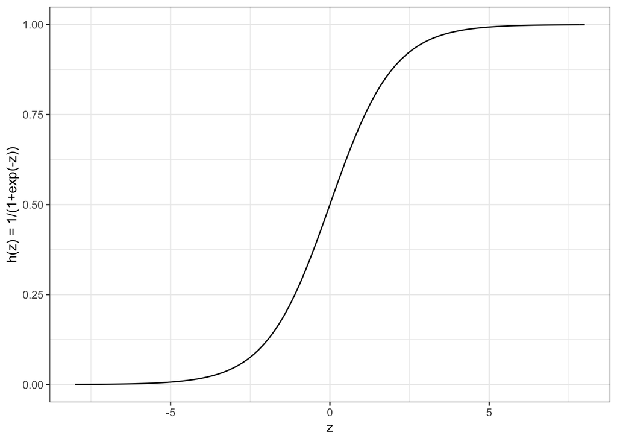

```r
library(ggplot2)
library(ggridges)

base <- ggplot() + xlim(-8, 8)
base + geom_function(fun = sigmoid) +
  #facet_wrap(vars(genus)) +
  labs(#title = "Observed genera through time",
       x = "z",
       y = "h(z) = 1/(1+exp(-z))") +
  theme_bw()
```

Cuando el modelo predice de manera incorrecta el valor de la función `loss` es cercano a `9.2`. Es decir, si predice cercano a `1` y el valor real es `0`. O bien, cuando predice cercano a cero y el valor real es 1:

#### Función `loss`

```r
loss <- function(y_hat, y){
  loss <- -1 * (y * log(y_hat) + (1-y) * log(1-y_hat))
  return(loss)
}
```

Gráfica de la función `loss` para $x \in (0, 1)$:

```r
x <- seq(0.0001, 0.9999, length=100)
`y_1` <- loss(x, 1)
`y_0` <- loss(x, 0)

data <- data.frame(x, `y_0`, `y_1`) %>%
  gather("y_real", "y_est", -x)
```

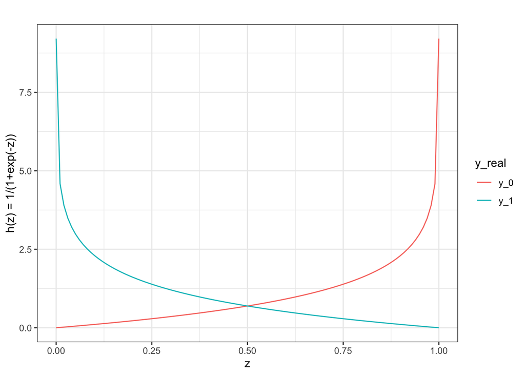

```r
base <- ggplot() + xlim(-0, 1)
ggplot(data,
       mapping = aes(x = x, y = y_est, color = y_real)) +
  geom_line() +
  theme_bw() +
  labs(title = "",
       x = "z",
       y = "h(z) = 1/(1+exp(-z))") +
  theme_bw()
```

#### Descenso de gradiente

```r
gradientDescent <- function(x, y, theta, alpha, num_iters){
  m = nrow(x)
  #y = y %>% t() %>% as.vector()
  for (i in 1:num_iters){
    z = x %*% theta
    h = sigmoid(z)
    J = -(1/m) * (t(y) %*% log(h) + (1-t(y)) %*% log(1-h))
    theta = theta - (1 * alpha/m) * (t(x) %*% (h-y))
  }
  return(list(J, theta))
}
```

Para probar la función descenso de gradiente se utilizaron los mismos valores que en el proyecto original. Se obtuvieron los mismos resultados.

```r
tmp_X = matrix(
  c(1, 8.34044009e+02, 1.44064899e+03,
    1, 2.28749635e-01, 6.04665145e+02,
    1, 2.93511782e+02, 1.84677190e+02,
    1, 3.72520423e+02, 6.91121454e+02,
    1, 7.93534948e+02, 1.07763347e+03,
    1, 8.38389029e+02, 1.37043900e+03,
    1, 4.08904499e+02, 1.75623487e+03,
    1, 5.47751864e+01, 1.34093502e+03,
    1, 8.34609605e+02, 1.11737966e+03,
    1, 2.80773877e+02, 3.96202978e+02),
  nrow = 10, byrow = TRUE)

tmp_Y = c(1, 1, 0, 1, 1, 1, 0, 0, 0, 1)
```

Costo después del entrenamiento

```r
gradientDescent(tmp_X, tmp_Y, rep(0, 3), 1e-8, 700)[[1]] %>%
  print()
```

```
##           [,1]
## [1,] 0.6709497
```

Vector de pesos

```r
as.vector(gradientDescent(tmp_X, tmp_Y, rep(0, 3), 1e-8, 700)[[2]]) %>%
  print()
```

```
## [1] 4.107134e-07 3.565847e-04 7.308885e-05
```

# Part 2: Extracting the features

## Extract Features

```r
extract_features <- function(tweet, dict){
  word_l = process_tweet(tweet)
  x <- rep(1, 3)

  temp <- dict %>%
    filter(words %in% word_l) %>%
    select(pos, neg)

  x[2] <- temp$pos %>% sum()
  x[3] <- temp$neg %>% sum()
  return(x)
}
```

Prueba la función:

```r
tweet.test <- "#FollowFriday @France_Inte @PKuchly57 @Milipol_Paris for being top engaged members in my community this week :)"
extract_features(tweet.test, freqs)
```

```
## [1]    1 2802   58
```

Si bien los resultados no son idénticos debido a diferencias entre el stemming entre `R` y `python`, los resultados son semilares.

Por ejemplo, en el tweet de prueba, la diferencia radica en una palabra: *communiti*; en `python` es *comun*.

```r
freqs %>%
  filter(words %in% process_tweet(tweet.test))
```

```
##     X        words    n  pos neg
## 1   2           :) 2630 2630   0
## 2  51         week  120   73  47
## 3 244          top   33   29   4
## 4 289    communiti   27   26   1
## 5 341 followfriday   23   23   0
## 6 388       member   20   14   6
## 7 933        engag    7    7   0
```

Ahora, se prueba la función con palabras que no están en el diccionario:

```r
extract_features('blorb bleeeeb bloooob', freqs)
```

```
## [1] 1 0 0
```

# Part 3: Entrenando el modelo

```r
X <- rep(0, 3*nrow(train.df)) %>%
  matrix(nrow = nrow(train.df))
colnames(X) <- c("bias", "pos", "neg")

for (i in 1:nrow(train.df)){
  X[i, ]= extract_features(train.df[i, ], freqs)
}

# training labels corresponding to X
y = train.y %>% t() %>% as.vector()
```

Se aplica la función gradiente:

```r
# Apply gradient descent
temp <- gradientDescent(X, y, rep(0, 3),
                alpha = 1e-9, num_iters = 1500)

J <- temp[[1]]
theta <- temp[[2]] %>%
  as.vector()
```

# Part 4: Test your logistic regression

```r
predict_tweet <- function(tweet, dict, theta){
    x = extract_features(tweet, dict)
    y_pred = sigmoid(x %*% theta)
    return (y_pred)
}
```

```r
# Run this cell to test your function
tweets.test <- c("I am happy", "I am bad", "this movie should have been great.", "great", "great great", "great great great", "great great great great")

for(i in 1:length(tweets.test)){
  paste(tweets.test[i],
        "-->",
        predict_tweet(tweets.test[i], freqs, theta)) %>%
    print()
}
```

```
## [1] "I am happy --> 0.516660373258764"
## [1] "I am bad --> 0.49433671291424"
## [1] "this movie should have been great. --> 0.513948945629976"
## [1] "great --> 0.51420060825516"
## [1] "great great --> 0.51420060825516"
## [1] "great great great --> 0.51420060825516"
## [1] "great great great great --> 0.51420060825516"
```

```r
test_logistic_regression <- function(test_x, test_y, dict, theta){
  test_x <- test_x %>% as.vector() %>% t()
  y_hat = rep(0, length(test_y))
  i <- 2
  for (i in 1:length(test_x)){
      y_pred = predict_tweet(test_x[i], dict, theta)

      if (y_pred > 0.5) y_hat[i] <- 1
  }

  accuracy = mean(y_hat == test_y)
  return (accuracy)
}

test.y <- test.y %>% t() %>% as.vector()
tmp_accuracy <- test_logistic_regression(test.df, test.y, freqs, theta)
tmp_accuracy
```

```
## [1] 0.931
```

# Part 5: Error Analysis

```r
# Some error analysis done for you
print('Label Predicted Tweet')

test.x <- test.df %>% as.vector() %>% t()

for(i in 1:length(test.x)){
  for(i in 1:length(test.y)){
    y_hat = predict_tweet(test.x, freqs, theta)
    if (abs(y - (y_hat > 0.5)) > 0){
      print('THE TWEET IS:', x)
      print('THE PROCESSED TWEET IS:', process_tweet(x))
      #print('%d\t%0.8f\t%s' % (y, y_hat,)
    }
  }
}
```

[output not shown]

Referencias:

- Text mining

https://www.cienciadedatos.net/documentos/38_text_minig_con_r_ejemplo_practico_twitter

- Regresión Lineal

https://rpubs.com/Joaquin_AR/229736#

Expresiones regulares

- https://rpubs.com/ydmarinb/429756#

Stopwords

- https://www.rdocumentation.org/packages/stopwords/versions/2.2

Replace emoticons

- https://rdrr.io/cran/textclean/man/replace_emoticon.html

Stemming words

- https://cran.r-project.org/web/packages/corpus/vignettes/stemmer.html
- https://www.rdocumentation.org/packages/quanteda/versions/1.3.0/topics/tokens
- Emoticones

https://en.wikipedia.org/wiki/List_of_emoticons

- Crear un diccionario

https://rpubs.com/MaVa/362475

- Sentimientos

https://programminghistorian.org/es/lecciones/analisis-de-sentimientos-r